# STRI Champaign Project 2019

## Social Research and Technology Innovation Laboratory (STRI) Data Analytics

Champaign Municipality City Works Complaints Data

This notebook provides data visualizations from Champaign County in Illinois for public city work complaints. The data were provided by the city of of Champaign and provide information on the description of the complaint, time of complaint, time complaint was closed, and geo-spatial data. In this notebook, the data are cleaned, processed, and visualized to provide insight on public work issues in the local Champaign area. The findings are intended to assist the local community leaders in making decisions on how to improve the community environment. [https://srtilab.techservices.illinois.edu/about/]

*** THE DATA PROVIDED HERE ARE UPDATED WITH 2018 DATA & MONTH BREAKDOWNS.

```python
# standard imports
import pandas as pd
from matplotlib.pyplot import suptitle
import numpy as np
import seaborn as sns
import matplotlib
import numpy as np
import matplotlib.pyplot as plt
import warnings
warnings.filterwarnings('ignore')
#warnings.filterwarnings(action='once')

%matplotlib inline
```

- Data Exploration and Cleaning
  - Continued Exploration
- Graph Common Complaints
- Top Issues by Month (New)
- Top Issues by Year
- Complaints by Addresses
- Geographic Data
- Data Visualizations from Tableau
- Contact STRI

[Back to TOC]

## Data Exploration and Cleaning

This data represents data from Champaign municipality. In this section, I clean, explore, and organize the data. OUr data contains information on location, status, date, and descriptions of complaints in the local area.

```python
# read in the UPDATED cityworks file, with data from 2018
cityWorks = pd.read_excel("CityWorks_2019.xlsx")
```

```python
# Check out head of data
cityWorks.head()
```

|  | # of SR | DESCRIPTION | DATETIMEINIT | DATETIMECLOSED | STATUS | PROBADDRESS | PROBLOCATION | SRX | SRY |
| --- | --- | --- | --- | --- | --- | --- | --- | --- | --- |
| 0 | 13 | Pick up abandoned bicycle(s) | 2009-11-17 07:21:25 | 2009-11-18 15:22:26 | CLOSED | 1315 GARDEN LN | NaN | 1008919.0 | 1261101.0 |
| 1 | 14 | Clean inlet | 2009-11-17 07:47:23 | 2009-12-16 13:45:34 | CLOSED | HONEYSUCKLE LN / MELANIE LN | NaN | 1002170.0 | 1262855.0 |
| 2 | 15 | Clean inlet | 2009-11-17 08:18:05 | 2009-11-17 15:38:28 | CLOSED | HOLIDAY DR / W WILLIAM ST | NaN | 997293.0 | 1256055.0 |
| 3 | 16 | Clean inlet | 2009-11-17 08:33:07 | 2009-11-17 15:10:54 | CLOSED | IVY / S MATTIS AVE | NaN | 1000180.0 | 1246565.0 |
| 4 | 17 | Clean inlet | 2009-11-17 08:46:17 | 2009-11-17 15:23:44 | CLOSED | 708 BALBOA DR | NaN | 1006325.0 | 1248570.0 |

```python
# Check out tail
# We can see we have some missing inputs
cityWorks.tail(3)
```

|  | # of SR | DESCRIPTION | DATETIMEINIT | DATETIMECLOSED | STATUS | PROBADDRESS | PROBLOCATION | SRX | SRY |
| --- | --- | --- | --- | --- | --- | --- | --- | --- | --- |
| 35000 | 35161 | Sewer backup | 2018-12-24 15:30:00 | 2018-12-28 14:15:40 | CLOSED | 1502 Queens Way | NaN | 1001302.940 | 1266625.460 |
| 35001 | 35162 | All other traffic service requests | 2018-12-27 06:30:00 | NaT | OPEN | 600 W Kirby Ave | NaN | 1006921.240 | 1249657.840 |
| 35002 | 35163 | Pothole repair | 2018-12-28 16:16:19 | NaT | OPEN | I74 & N Mattis Ave | NaN | 999903.426 | 1265067.889 |

[Back to TOC]

## Continued Exploration

Here, the data are explored to give an indication of popular issues, unpopular issues, the spread of the data, and so forth. I begin by viewing common problems, giving an idea of how to best visualize the data.

```python
# print the top complaints
cityWorks['DESCRIPTION'].value_counts().head(15)
```

```
Pothole repair                                     3993
Sewer backup                                       2673
Pick up dead animal(s)                             2339
Pick up miscellaneous debris                       1725
Tree inspection                                    1509
Misc. request/problem involving City facilities     977
Tree branch on ROW needs to picked up               974
Request to repair a burnt out streetlight lamp      965
Tree pruning                                        955
Snow & Ice mailbox repair                           850
Clean inlet                                         806
Tree removal                                        759
Pick up abandoned bicycle(s)                        752
Plow request                                        703
Signal not cycling properly                         650
Name: DESCRIPTION, dtype: int64
```

```python
# print the least common complaints
cityWorks['DESCRIPTION'].value_counts().tail(5)
```

```
Report of a burnt out light in the taffic signal    1
Hang up banner                                      1
Special project for another government agency       1
Bleeding street                                     1
PW repairs/improvements                             1
Name: DESCRIPTION, dtype: int64
```

[Back to TOC]

## Graph Common Complaints

Use Seaborn to graph out the most common complaint descriptions (they occur over 500 times) and the least common complaint descriptions.

```python
# Take only descriptions where there are over 500 instances
description_over_500 = cityWorks.groupby('DESCRIPTION').filter(lambda x:len(x) > 500)
```

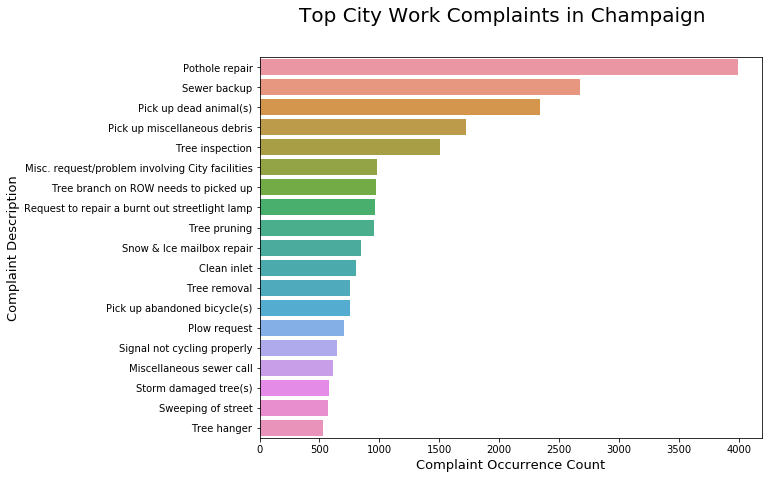

```python
# Create a plot of the top city works complaints
f, ax = plt.subplots(figsize=(9, 7))
ax = sns.countplot(y="DESCRIPTION", data=description_over_500,
                   order=description_over_500['DESCRIPTION'].value_counts().index)
#ax.set_xticklabels(ax.get_xticklabels(),rotation=90)
ax.set_xlabel("Complaint Occurrence Count", size=13)
ax.set_ylabel("Complaint Description", size=13)
suptitle("Top City Work Complaints in Champaign", size=20)
fig = ax.get_figure()

#fig.savefig("topcityworksplot",bbox_inches="tight")
```

```python
# Create a plot of the top city works complaints
# Take only complaints where there are less than 6
description_under_6 = cityWorks.groupby('DESCRIPTION').filter(lambda x:len(x) < 6)
```

```
In the output below, we see issues that occur an average of five times or less:
```

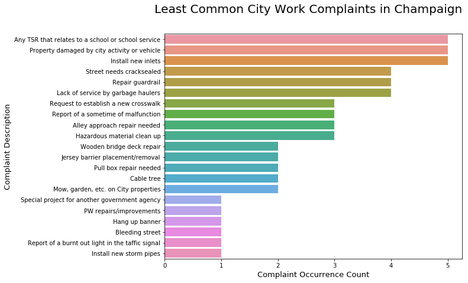

```python
print("In the output below, we see issues that occur an average of five times or less:")
print("")

# graph the least common complaints
f, ax = plt.subplots(figsize=(9, 7))
ax = sns.countplot(y="DESCRIPTION", data=description_under_6,
                   order=description_under_6['DESCRIPTION'].value_counts().index)
#ax.set_xticklabels(ax.get_xticklabels(),rotation=90)
ax.set_xlabel("Complaint Occurrence Count", size=13)
ax.set_ylabel("Complaint Description", size=13)
suptitle("Least Common City Work Complaints in Champaign", size=20)
fig = ax.get_figure()

#fig.savefig("topcityworksplot",bbox_inches="tight")
```

[Back to TOC]

## Top Issues by Month [New]

In this section, I will review top issues by month. This will allow Champaign public works officials to optimize resources for pressing and recurring issues every month; for instance, perhaps we find in December that issues realted to ice are prevelant.

```python
# Extract month information from datetime column
cityWorks['month_int'] = cityWorks['DATETIMEINIT'].map(lambda x: x.month)
```

```python
# see sample of results for new row "month_int"
cityWorks.sample(3)
```

|  | # of SR | DESCRIPTION | DATETIMEINIT | DATETIMECLOSED | STATUS | PROBADDRESS | PROBLOCATION | SRX | SRY | month_int |
| --- | --- | --- | --- | --- | --- | --- | --- | --- | --- | --- |
| 7734 | 7771 | Sweeping of street | 2012-01-23 08:29:10 | 2012-01-26 04:10:10 | CLOSED | 2600 CAMPBELL DR | NaN | 1001892.0 | 1266364.0 | 1 |
| 15031 | 15124 | Request to repair a burnt out streetlight lamp | 2013-09-05 12:59:36 | 2013-09-06 07:34:25 | CLOSED | S PRAIRIE ST & W GREEN ST | STREET LIGHT REPORTED OUT ON SOUTH SIDE OF ST... | 1007998.9 | 1254045.9 | 9 |
| 128 | 143 | Tree pruning | 2009-12-11 11:31:20 | 2009-12-14 13:47:34 | CLOSED | 1707 W PARK AVE | NaN | 1000384.0 | 1256605.0 | 12 |

```python
# Create transformation to transform numerals into month names
def Month (row):
    if row['month_int'] == 1:
        return 'January'
    if row['month_int'] == 2:
        return 'February'
    if row['month_int'] == 3:
        return 'March'
    if row['month_int'] == 4:
        return 'April'
    if row['month_int'] == 5:
        return 'May'
    if row['month_int'] == 6:
        return 'June'
    if row ['month_int'] == 7:
        return 'July'
    if row['month_int'] == 8:
        return 'August'
    if row['month_int'] == 9:
        return 'September'
    if row['month_int'] == 10:
        return 'October'
    if row['month_int'] == 11:
        return 'November'
    if row['month_int'] == 12:
        return 'December'
```

```python
# Now apply the function to the dataframe, but first check that results are accurate
cityWorks.apply(lambda row: Month (row), axis=1).head(2)
```

```
0    November
1    November
dtype: object
```

```python
# Create new row in the cityworks dataframe with our Month column
cityWorks['Month'] = cityWorks.apply(lambda row: Month (row), axis=1)
```

```python
# Output looks good, a month row has been included
cityWorks.sample(3)
```

|  | # of SR | DESCRIPTION | DATETIMEINIT | DATETIMECLOSED | STATUS | PROBADDRESS | PROBLOCATION | SRX | SRY | month_int | Month |
| --- | --- | --- | --- | --- | --- | --- | --- | --- | --- | --- | --- |
| 14974 | 15067 | Misc. electrical request | 2013-08-29 08:09:56 | 2013-08-29 08:30:43 | CLOSED | W CURTIS RD / S DUNCAN RD | NaN | 994964.43 | 1239195.33 | 8 | August |
| 13099 | 13176 | Misc. traffic request | 2013-05-17 16:16:35 | 2013-08-12 14:50:18 | CLOSED | ALTON DR & NOFFTZ DR | Corner of Alton and Nofftz Dr. | 997206.80 | 1251640.50 | 5 | May |
| 6666 | 6700 | Inspect manhole | 2011-09-14 09:20:08 | 2011-09-15 10:03:40 | CLOSED | 608 GOLDENVIEW DR | NaN | 993086.00 | 1254121.00 | 9 | September |

```
In the output below, we see relatively low complaints in the winter, and a spike during the summer:
```

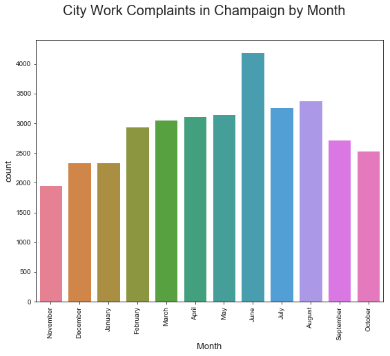

```python
# create a plot for number of complaints by Month
print("In the output below, we see relatively low complaints in the winter, and a spike during the summer:")
print("")

# create plot
f, ax = plt.subplots(figsize=(9, 7))
sns.set(style="whitegrid")
ax.set_xlabel("Month", size=13)
ax.set_ylabel("Complaint Count", size=13)
suptitle("City Work Complaints in Champaign by Month", size=20)
ax = sns.countplot(x="Month", data=cityWorks, palette='husl')
plt.xticks(rotation=90)

fig = ax.get_figure()

#fig.savefig("cityworkcomplaintsbyyear",bbox_inches="tight")
```